# HW#2

Homework 2

Lutfi Syahreza Lubis

### Task 1

```python
a = [1, 'A', True, 'Good_News', ['Great', 'News',], None]
```

```python
a[-2][0]
```

```
'Great'
```

```python
a[-2]
```

```
['Great', 'News']
```

```python
a[-2][1]
```

```
'News'
```

```python
a[-2][0][-2:]
```

```
'at'
```

a. the first two elements of the list

```python
a[0:2]
```

```
[1, 'A']
```

b. the last element of the list

```python
print(a[-1])
```

```
None
```

```python
type(a[-1])
```

```
NoneType
```

c. the second to last element of the list

```python
a[-2]
```

```
['Great', 'News']
```

d. the second to the second to last element

```python
a[-3]
```

```
'Good_News'
```

e. every othe letter in 'Great'

```python
a[-2][0][::2]
```

```
'Get'
```

f. the fist three list elemens in reverse order

```python
a[2::-1]
```

```
[True, 'A', 1]
```

### 2. URL for the data set containing solar radiation datafor the eclipse

url = 'http://skywatch.colorado.edu/data/spn/spn_17_08_21.dat'

### 3. Import module to handle fecthing data from the web

import urllib.request

### 4. Open the URL and read all the lines from the data into lines variable

lines = urllib.request.urlopen(url).readlines()

### 5. Loop over the lines in the file

#### 6. Initialize list for times

utc=[]

#### 8. Decode the line from binary format to UTF-8 and split it by comma to separate the field

```
entries = line.decode("utf-8").split(',')
```

#### 9. print(entries);quit()

#### 10. If the first character of the line is not a semicolon, process the line

```
if entries[0][0] != ';':
```

#### 11. Convert the time string into decimal hours (HH:MM:SS)

#### 12. Append the result into the utc list

```
    utc.append(float(entries[0][0:2]) + \
               float(entries[0][3:5])/60. + \
               float(entries[0][6:8])/3600.)
```

#### 13. Convert the second column as the solar radiation data and append it to tti list tti.append(float(entries[1]))

### Task 3

```python
import matplotlib.pyplot as plt
import numpy as np


url    = 'https://skywatch.colorado.edu/data/pyrgeometer/pyrg_17_08_21.dat'

import urllib.request
lines  = urllib.request.urlopen(url).readlines()

# Loop over the lines in the file
utc=[] # initialize list for times
irradiance =[] # initialize list for radiation
for line in lines:
    entries = line.decode("utf-8").split('\t')
    #print(entries);quit()
    if entries[0][0] != ';':
        #taking the first two elements or hours
         # Convert time to decimal hours
        utc.append(float(entries[0][0:2]) +
                   float(entries[0][3:5])/60. +
                   float(entries[0][6:8])/3600.)
        irradiance.append(float(entries[1]))
```

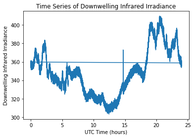

```python
# Plotting the time series
plt.plot(utc, irradiance)
plt.xlabel('UTC Time (hours)')
plt.ylabel('Downwelling Infrared Irradiance')
plt.title('Time Series of Downwelling Infrared Irradiance')
plt.show()
```

```python
# Sub-setting the data to the time range 18-22 UTC
time_range_indices = np.where((np.array(utc) >= 18) & (np.array(utc) <= 22))

# Subset the actual UTC and irradiance values
subset_utc = np.array(utc)[time_range_indices]
subset_irradiance = np.array(irradiance)[time_range_indices]
```

```python
i = 0
total = 0

# 1. Calculating mean and standard deviation using a loop
for value in subset_irradiance:
    total += value
    i += 1

mean_loop = total / i

# 2. Calculating standard deviation using a loop
var_sum = 0
for value in subset_irradiance:
    var_sum += (value-mean)**2

std_loop = (var_sum/i)**0.5

print("mean using loop:", mean_loop)
print("standar deviation using loop:", std_loop)
```

[output not shown]

```python
# 3. Calculating mean and standard deviation using numpy
mean_numpy = np.mean(subset_irradiance)
std_numpy = np.std(subset_irradiance)
```

```python
print("Mean (loop):", mean_loop)
print("Standard Deviation (loop):", std_loop)
print("Mean (numpy):", mean_numpy)
print("Standard Deviation (numpy):", std_numpy)
```

```
Mean (loop): 385.0556986505732
Standard Deviation (loop): 38.71993498455553
Mean (numpy): 385.05569865057305
Standard Deviation (numpy): 15.741144935913551
```